# Modeling

In some articles, we knew that weather affect crime rate. For example, the hotter the weather is, the more likely people are to commit crimes. The worse the weather is, the less likely people are to go out and commit crimes. Here we want to predict number of crimes each day in New York as our outcome and precipitation, snow depth, maximum temperature and minimum temperature as predictors.

First, let’s check the distribution of number of crime cases each day in New York

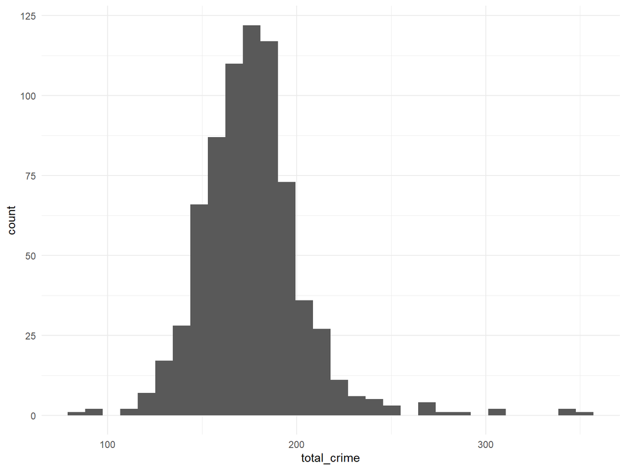

```r
ggplot(data = crime_weather,aes(x = total_crime)) + geom_histogram()
```

From the distribution of daily cases, we noticed that it is approximately normally distributed, therefore we don’t need to transform the value of the outcome.

First we use scatter plot to investigate the association between weather and cases and crime

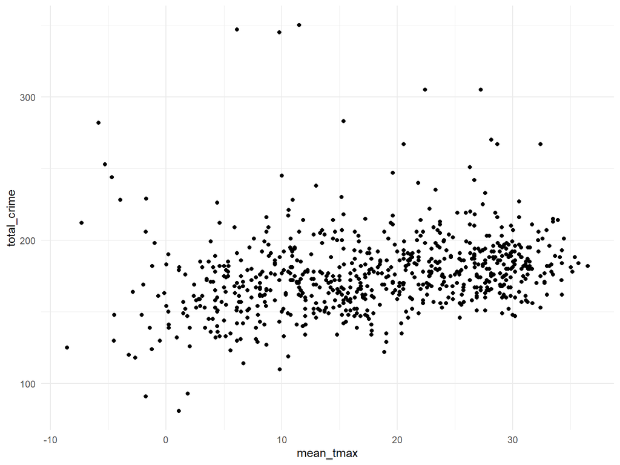

```r
ggplot(crime_weather, aes(x = mean_tmax, y = total_crime)) + geom_point()
```

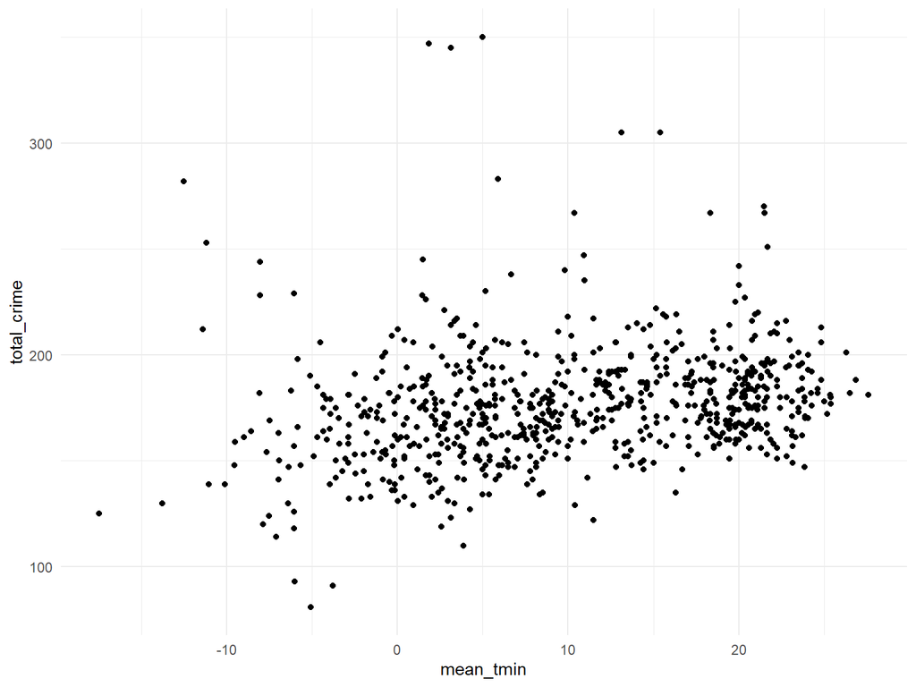

```r
ggplot(crime_weather, aes(x = mean_tmin, y = total_crime)) + geom_point()
```

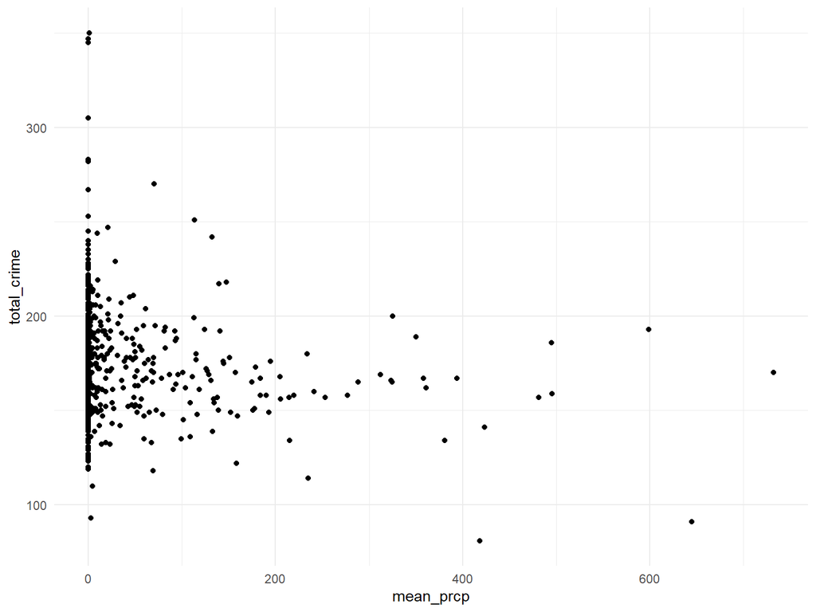

```r
ggplot(crime_weather, aes(x = mean_prcp, y = total_crime)) + geom_point()
```

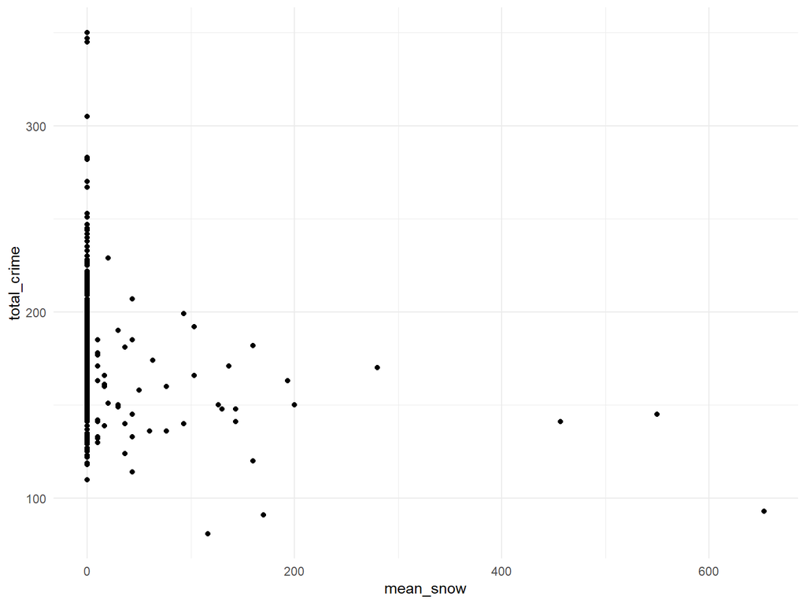

```r
ggplot(crime_weather, aes(x = mean_snow, y = total_crime)) + geom_point()
```

## Fitting Model

Firstly, I use month, weekdays and all weather data as predictors

```r
full_model = lm(total_crime ~ mon + day_of_week + mean_tmin + mean_tmax + mean_prcp + mean_snow, data = crime_weather)
summary(full_model) %>%
  broom::tidy() %>%
  knitr::kable(digits = 2)
```

| term | estimate | std.error | statistic | p.value |
| --- | --- | --- | --- | --- |
| (Intercept) | 175.11 | 4.21 | 41.60 | 0.00 |
| mon | 1.62 | 0.28 | 5.82 | 0.00 |
| day_of_weekMonday | -24.68 | 3.39 | -7.27 | 0.00 |
| day_of_weekSaturday | -17.22 | 3.39 | -5.09 | 0.00 |
| day_of_weekSunday | -25.64 | 3.39 | -7.57 | 0.00 |
| day_of_weekThursday | -14.88 | 3.40 | -4.38 | 0.00 |
| day_of_weekTuesday | -16.58 | 3.40 | -4.88 | 0.00 |
| day_of_weekWednesday | -8.48 | 3.40 | -2.49 | 0.01 |
| mean_tmin | 0.07 | 0.37 | 0.18 | 0.86 |
| mean_tmax | 0.42 | 0.34 | 1.21 | 0.23 |
| mean_prcp | -0.05 | 0.01 | -4.31 | 0.00 |
| mean_snow | -0.07 | 0.02 | -2.96 | 0.00 |

I noticed that both tmax and tmin are not significant, which may be attributed to their correlation, so I calculated the VIF.

```r
vif(full_model) %>%
  knitr::kable()
```

|  | GVIF | Df | GVIF^(1/(2*Df)) |
| --- | --- | --- | --- |
| mon | 1.12 | 1 | 1.06 |
| day_of_week | 1.03 | 6 | 1.00 |
| mean_tmin | 13.95 | 1 | 3.73 |
| mean_tmax | 13.70 | 1 | 3.70 |
| mean_prcp | 1.06 | 1 | 1.03 |
| mean_snow | 1.08 | 1 | 1.04 |

It is obvious that the VIF of tmin and tmax is high, so I chose to drop tmin.

The second proposed model is total_crime ~ mon + day_of_week + mean_tmax + mean_prcp + mean_snow

```r
model1 = lm(total_crime ~ mon + day_of_week + mean_tmax + mean_prcp + mean_snow, data = crime_weather)
summary(model1) %>%
  broom::tidy() %>%
  knitr::kable(digits = 2)
```

| term | estimate | std.error | statistic | p.value |
| --- | --- | --- | --- | --- |
| (Intercept) | 174.64 | 3.33 | 52.49 | 0.00 |
| mon | 1.63 | 0.27 | 5.97 | 0.00 |
| day_of_weekMonday | -24.70 | 3.39 | -7.29 | 0.00 |
| day_of_weekSaturday | -17.20 | 3.38 | -5.09 | 0.00 |
| day_of_weekSunday | -25.64 | 3.38 | -7.58 | 0.00 |
| day_of_weekThursday | -14.87 | 3.40 | -4.38 | 0.00 |
| day_of_weekTuesday | -16.55 | 3.39 | -4.88 | 0.00 |
| day_of_weekWednesday | -8.50 | 3.40 | -2.50 | 0.01 |
| mean_tmax | 0.48 | 0.10 | 4.91 | 0.00 |
| mean_prcp | -0.05 | 0.01 | -4.38 | 0.00 |
| mean_snow | -0.07 | 0.02 | -2.96 | 0.00 |

This time, the tmax becomes significant. And it has a positive effect on crime rate, which validate our assumption.

We also proposed other models

What if the snow depth is not included in the model?

```r
model2 = lm(total_crime ~ mon +day_of_week +  mean_tmax + mean_prcp, data = crime_weather)
summary(model2) %>%
  broom::tidy() %>%
  knitr::kable(digits = 2)
```

| term | estimate | std.error | statistic | p.value |
| --- | --- | --- | --- | --- |
| (Intercept) | 172.50 | 3.26 | 52.84 | 0.00 |
| mon | 1.76 | 0.27 | 6.50 | 0.00 |
| day_of_weekMonday | -24.90 | 3.41 | -7.31 | 0.00 |
| day_of_weekSaturday | -17.25 | 3.40 | -5.07 | 0.00 |
| day_of_weekSunday | -26.05 | 3.40 | -7.66 | 0.00 |
| day_of_weekThursday | -14.83 | 3.41 | -4.34 | 0.00 |
| day_of_weekTuesday | -16.66 | 3.41 | -4.89 | 0.00 |
| day_of_weekWednesday | -8.51 | 3.41 | -2.49 | 0.01 |
| mean_tmax | 0.53 | 0.10 | 5.53 | 0.00 |
| mean_prcp | -0.05 | 0.01 | -4.38 | 0.00 |

We also want to try to include a interaction term in our model.

```r
model3 <- lm(total_crime ~  mon +day_of_week +  mean_tmax + mean_prcp + mean_snow + mean_tmax*day_of_week, data = crime_weather )
summary(model3) %>%
    broom::tidy() %>%
  knitr::kable(digits = 2)
```

| term | estimate | std.error | statistic | p.value |
| --- | --- | --- | --- | --- |
| (Intercept) | 181.12 | 5.04 | 35.93 | 0.00 |
| mon | 1.61 | 0.27 | 5.91 | 0.00 |
| day_of_weekMonday | -35.96 | 7.02 | -5.13 | 0.00 |
| day_of_weekSaturday | -25.06 | 6.66 | -3.76 | 0.00 |
| day_of_weekSunday | -29.41 | 6.84 | -4.30 | 0.00 |
| day_of_weekThursday | -26.90 | 7.07 | -3.81 | 0.00 |
| day_of_weekTuesday | -27.56 | 7.04 | -3.92 | 0.00 |
| day_of_weekWednesday | -8.38 | 7.22 | -1.16 | 0.25 |
| mean_tmax | 0.11 | 0.24 | 0.48 | 0.63 |
| mean_prcp | -0.05 | 0.01 | -4.23 | 0.00 |
| mean_snow | -0.07 | 0.02 | -2.96 | 0.00 |
| day_of_weekMonday:mean_tmax | 0.63 | 0.35 | 1.83 | 0.07 |
| day_of_weekSaturday:mean_tmax | 0.45 | 0.33 | 1.35 | 0.18 |
| day_of_weekSunday:mean_tmax | 0.21 | 0.34 | 0.64 | 0.52 |
| day_of_weekThursday:mean_tmax | 0.67 | 0.34 | 1.95 | 0.05 |
| day_of_weekTuesday:mean_tmax | 0.62 | 0.35 | 1.79 | 0.07 |
| day_of_weekWednesday:mean_tmax | 0.02 | 0.35 | 0.06 | 0.96 |

In model 3 , we assume that there is an interaction between temperature and day of week, however, the interaction term are not significant.

We also want to know whether to include months and weekdays in our model.

```r
model4 <- lm(total_crime ~ mean_tmax + mean_prcp + mean_snow, data = crime_weather)
summary(model4) %>%
  broom::tidy() %>%
  knitr::kable(digits = 2)
```

| term | estimate | std.error | statistic | p.value |
| --- | --- | --- | --- | --- |
| (Intercept) | 168.17 | 2.15 | 78.15 | 0 |
| mean_tmax | 0.59 | 0.10 | 5.76 | 0 |
| mean_prcp | -0.05 | 0.01 | -4.31 | 0 |
| mean_snow | -0.09 | 0.02 | -4.05 | 0 |

## Cross Validation

We found the variables of all models except model 3 are all statistically significant, so we use cross validation to compare the models.

```r
cv_df <-
  crossv_mc(crime_weather, 100) %>%
  mutate(
    train = map(train, as_tibble),
    test = map(test, as_tibble)
  )
```

```r
cv_df <-
  cv_df %>%
  mutate(
    model1 = map( train, ~lm(total_crime ~ mon + day_of_week + mean_tmax + mean_prcp + mean_snow, data = crime_weather)),
    model2 =  map( train, ~lm(total_crime ~ mon +day_of_week +  mean_tmax + mean_prcp, data = crime_weather)),
    model4 = map( train, ~lm( total_crime ~ mean_tmax + mean_prcp + mean_snow, data = crime_weather))) %>%
   mutate(
    rmse_model1 = map2_dbl( model1,  test, ~rmse(model = .x, data =.y)),
    rmse_model2 = map2_dbl( model2,  test, ~rmse(model = .x, data =.y)),
    rmse_model4 = map2_dbl( model4, test, ~rmse(model = .x, data =.y))
  )
```

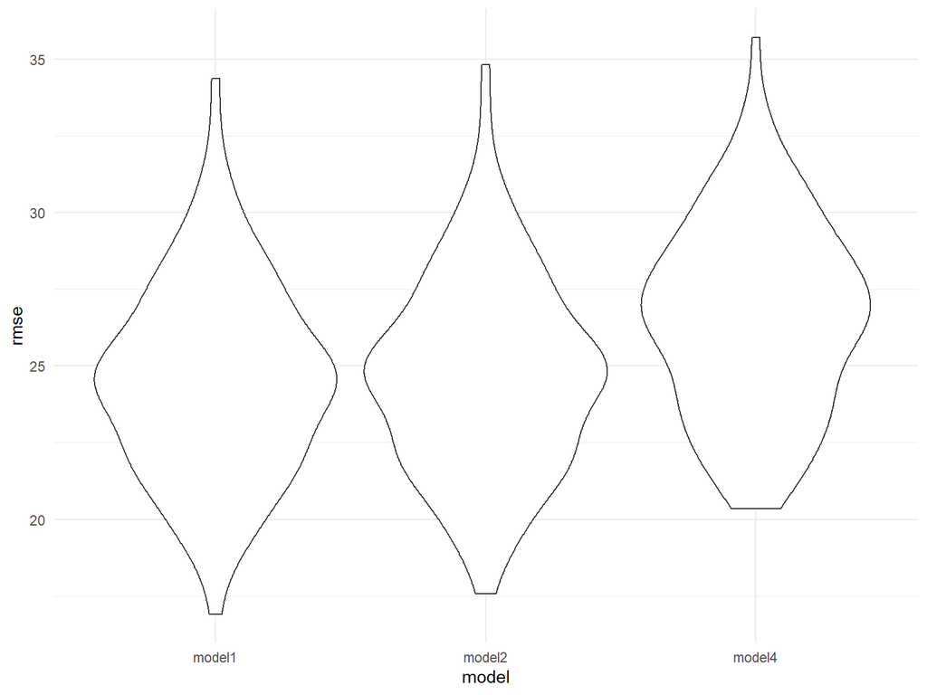

```r
cv_df %>%
  select(starts_with("rmse")) %>%
  pivot_longer(
    everything(),
    names_to = "model",
    values_to = "rmse",
    names_prefix = "rmse_") %>%
  mutate(model = fct_inorder(model)) %>%
  ggplot(aes(x = model, y = rmse)) + geom_violin()
```

```r
cv_df %>%
  summarize(
    rmse_1 = mean(rmse_model1),
    rmse_2 = mean(rmse_model2),
    rmse_3 = mean(rmse_model4)
  ) %>%
  knitr::kable()
```

| rmse_1 | rmse_2 | rmse_3 |
| --- | --- | --- |
| 24.5 | 24.7 | 26.6 |

We would say model1 will be better than the other two models because its root means square error seems to be smaller. Therefore, model1 could be useful for predicting the total number of crime cases each day in New York.